# Reproducible Research: Peer Assessment 1

## Loading and preprocessing the data

```r
dat.ori <- read.csv(file="activity.csv", header = TRUE ,na.strings="NA" )
str(dat.ori)
```

```
## 'data.frame':    17568 obs. of  3 variables:
##  $ steps   : int  NA NA NA NA NA NA NA NA NA NA ...
##  $ date    : Factor w/ 61 levels "2012-10-01","2012-10-02",..: 1 1 1 1 1 1 1 1 1 1 ...
##  $ interval: int  0 5 10 15 20 25 30 35 40 45 ...
```

```r
head(dat.ori)
```

```
##   steps       date interval
## 1    NA 2012-10-01        0
## 2    NA 2012-10-01        5
## 3    NA 2012-10-01       10
## 4    NA 2012-10-01       15
## 5    NA 2012-10-01       20
## 6    NA 2012-10-01       25
```

```r
dat.ori$date <-  as.Date(dat.ori$date)
head(dat.ori)
```

```
##   steps       date interval
## 1    NA 2012-10-01        0
## 2    NA 2012-10-01        5
## 3    NA 2012-10-01       10
## 4    NA 2012-10-01       15
## 5    NA 2012-10-01       20
## 6    NA 2012-10-01       25
```

## What is mean total number of steps taken per day?

```r
library(dplyr)
dat.day <- dat.ori %>%
        select(date, steps) %>%
        group_by(date) %>%
        summarise_each(funs(sum))
head(dat.day)
```

```
## Source: local data frame [6 x 2]
##
##         date steps
##       (date) (int)
## 1 2012-10-01    NA
## 2 2012-10-02   126
## 3 2012-10-03 11352
## 4 2012-10-04 12116
## 5 2012-10-05 13294
## 6 2012-10-06 15420
```

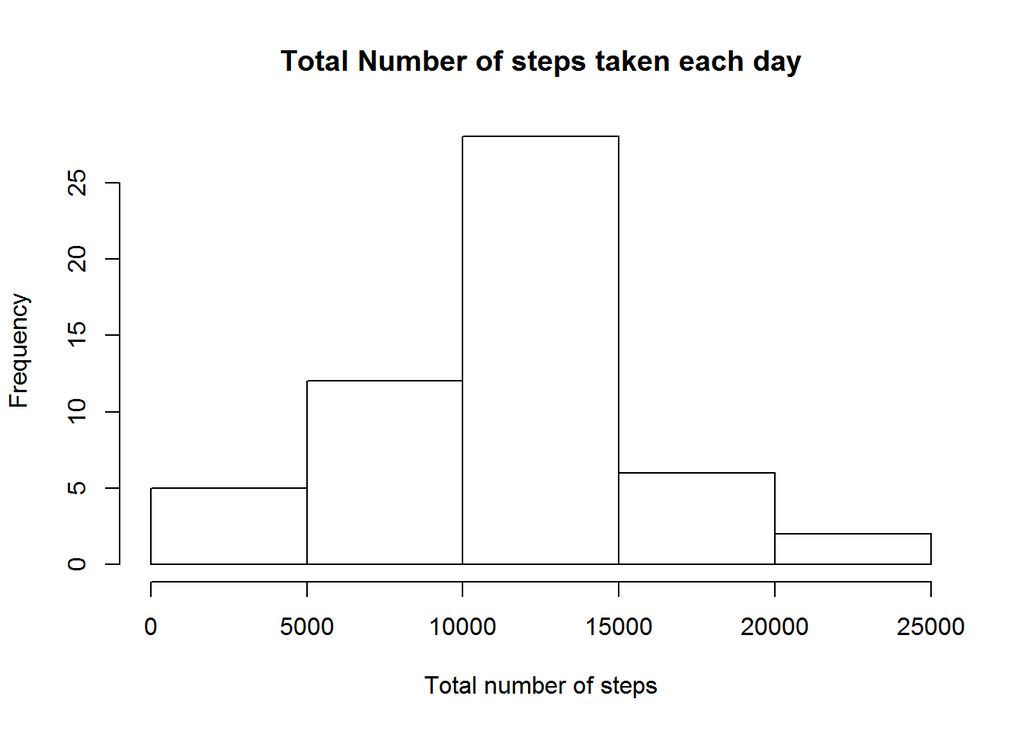

```r
hist(dat.day$steps,
     main="Total Number of steps taken each day",
     xlab="Total number of steps")
```

```r
dev.copy(png,  file  =  "figure/plot1.png")
```

```r
dev.off()
```

```r
summary(dat.day$steps)
```

```
##    Min. 1st Qu.  Median    Mean 3rd Qu.    Max.    NA's
##      41    8841   10760   10770   13290   21190       8
```

The mean total number of steps taken per day is 10770 steps. The median total number of steps taken per day is 10760 steps.

## What is the average daily activity pattern?

# Time series plot of the average number of steps taken

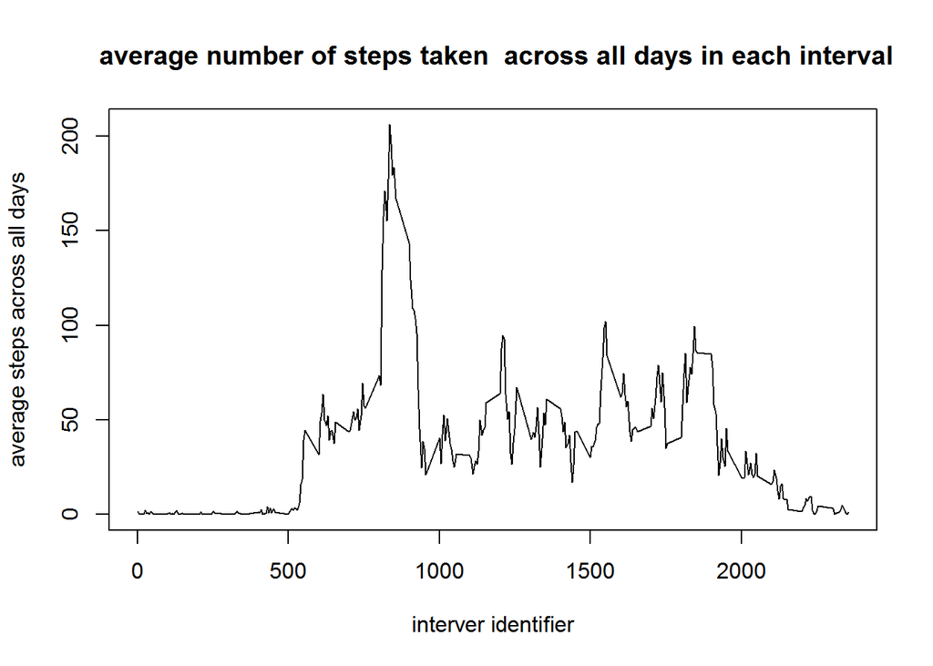

```r
dat.int <- dat.ori %>%
        select(steps, interval) %>%
        group_by(interval) %>%
        summarise_each(funs(mean(., na.rm = TRUE)))

plot(dat.int$interval,
     dat.int$steps,
     type="l",
     main =" average number of steps taken  across all days in each interval",
     xlab ="interver identifier",
     ylab="average steps across all days")
```

```r
dev.copy(png,  file  =  "figure/plot2.png")
```

```r
dev.off()
```

# The 5-minute interval that, on average, contains the maximum number of steps

```r
max.avgsteps <- max(dat.int$steps, na.rm = TRUE)
subset(dat.int, steps == max.avgsteps)
```

```
## Source: local data frame [1 x 2]
##
##   interval    steps
##      (int)    (dbl)
## 1      835 206.1698
```

The 835 5-minute interval, on average across all the days in the dataset, contains the maximum number of steps

## Imputing missing values

```r
dat.miss <- dat.ori[!complete.cases(dat.ori),]
nrow(dat.miss)
```

```
## [1] 2304
```

The total number of missing values in the dataset is 2304

```r
dat.imput <- merge(dat.miss,dat.int, by="interval")
head(dat.imput)
```

```
##   interval steps.x       date  steps.y
## 1        0      NA 2012-10-01 1.716981
## 2        0      NA 2012-11-30 1.716981
## 3        0      NA 2012-11-04 1.716981
## 4        0      NA 2012-11-09 1.716981
## 5        0      NA 2012-11-14 1.716981
## 6        0      NA 2012-11-10 1.716981
```

```r
dat.imput <- dat.imput[, c ("interval", "date", "steps.y")]
names(dat.imput) <- c("interval", "date", "steps")
head(dat.imput)
```

```
##   interval       date    steps
## 1        0 2012-10-01 1.716981
## 2        0 2012-11-30 1.716981
## 3        0 2012-11-04 1.716981
## 4        0 2012-11-09 1.716981
## 5        0 2012-11-14 1.716981
## 6        0 2012-11-10 1.716981
```

```r
nrow(dat.imput)
```

```
## [1] 2304
```

```r
nrow(dat.ori)
```

```
## [1] 17568
```

```r
nrow(dat.ori) - nrow(dat.imput)
```

```
## [1] 15264
```

```r
dat.complet<- na.omit(dat.ori)
nrow(dat.complet)
```

```
## [1] 15264
```

```r
dat.imput <- rbind(dat.imput, dat.complet)
nrow(dat.imput)
```

```
## [1] 17568
```